```python
%%html
<link rel="stylesheet" type="text/css" href="rise.css" />
```

Some imagess from **An Introduction to Statistical Learning** available at https://www-bcf.usc.edu/~gareth/ISL/ISLR%20First%20Printing.pdf

```python
import numpy as np
import matplotlib.pyplot as plt
%config InlineBackend.figure_format = 'retina'
plt.style.use('bmh')
plt.rcParams['lines.markeredgecolor'] = 'w'
plt.rcParams['lines.markeredgewidth'] = 0.5
plt.rcParams['figure.figsize'] = [8, 6]
plt.rcParams['lines.linewidth'] = 1.5
plt.rcParams['axes.labelsize'] = 14
plt.rcParams['axes.titlesize'] = 14
plt.rcParams['legend.fontsize'] = 12
```

# K-Nearest Neighbors (KNN) Regression

**Learning goals**

- You will be able to fit nonlinear {X0, X1, X2, ...} vs. Y data with a KNN model.
- You will be able to predict the Y value for new {X0, X1, X2, ...} values.
- You will appreciate that although a KNN model can be used to explain or predict lots of arbitrary nonlinear relations, it is less obvious what the model means.

K-Nearest Neighbors (KNN) regression

Model prediction is the mean of the K nearest data points.

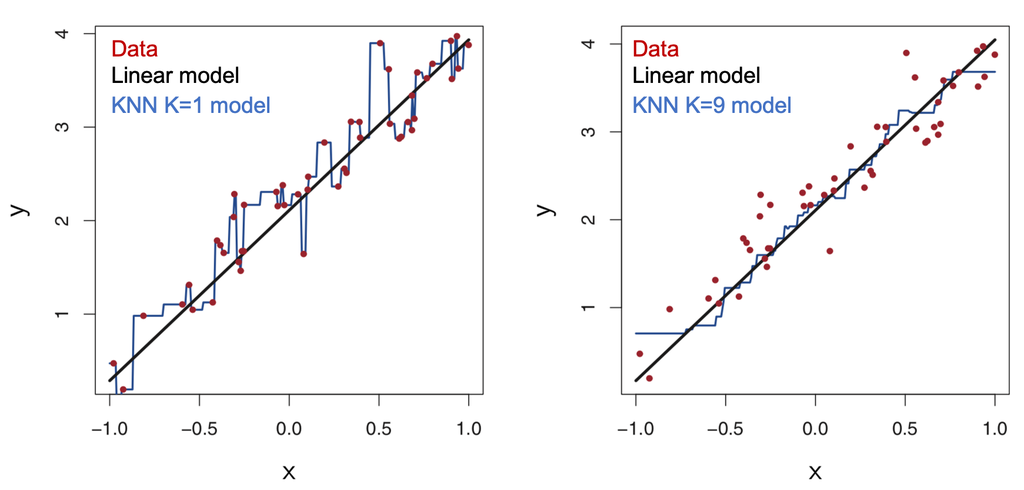

KNN can be used to model any kind of relation.

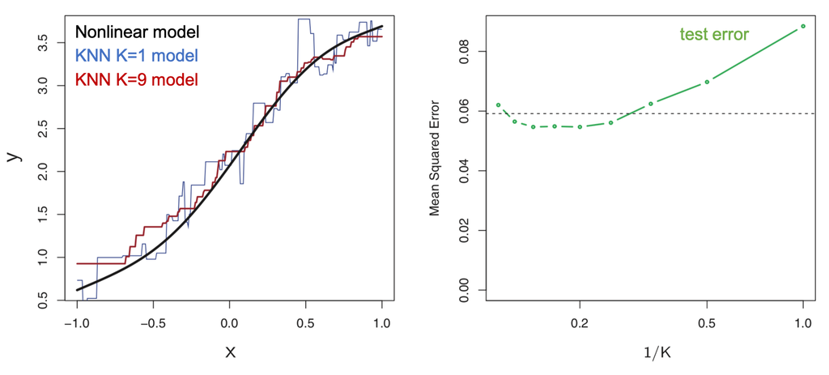

Consider data with multiple features.

True relationship (blue) and linear model (yellow).

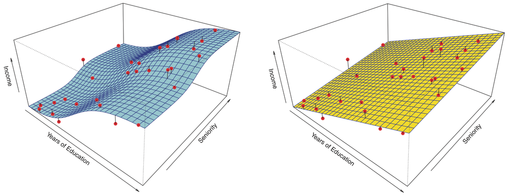

KNN models for multiple features.

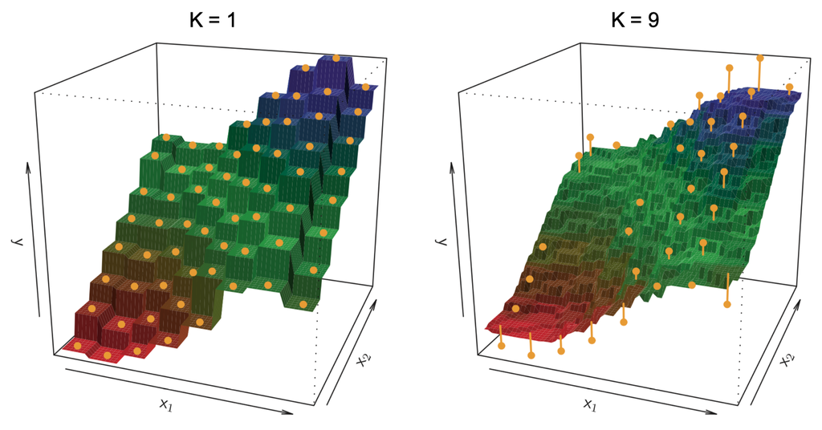

Diabetes dataset

```python
from sklearn import datasets
diabetes = datasets.load_diabetes()
print(diabetes.DESCR)
```

```
.. _diabetes_dataset:

Diabetes dataset
----------------

Ten baseline variables, age, sex, body mass index, average blood
pressure, and six blood serum measurements were obtained for each of n =
442 diabetes patients, as well as the response of interest, a
quantitative measure of disease progression one year after baseline.

**Data Set Characteristics:**

:Number of Instances: 442

:Number of Attributes: First 10 columns are numeric predictive values

:Target: Column 11 is a quantitative measure of disease progression one year after baseline

:Attribute Information:
    - age     age in years
    - sex
    - bmi     body mass index
    - bp      average blood pressure
    - s1      tc, total serum cholesterol
    - s2      ldl, low-density lipoproteins
    - s3      hdl, high-density lipoproteins
    - s4      tch, total cholesterol / HDL
    - s5      ltg, possibly log of serum triglycerides level
    - s6      glu, blood sugar level

Note: Each of these 10 feature variables have been mean centered and scaled by the standard deviation times the square root of `n_samples` (i.e. the sum of squares of each column totals 1).

Source URL:
https://www4.stat.ncsu.edu/~boos/var.select/diabetes.html

For more information see:
Bradley Efron, Trevor Hastie, Iain Johnstone and Robert Tibshirani (2004) "Least Angle Regression," Annals of Statistics (with discussion), 407-499.
(https://web.stanford.edu/~hastie/Papers/LARS/LeastAngle_2002.pdf)
```

```python
# features (X) are already standardized
X = diabetes.data
# target disease progression values are NOT standardized
y = diabetes.target

X.shape, y.shape
```

```
((442, 10), (442,))
```

```python
diabetes.feature_names
```

```
['age', 'sex', 'bmi', 'bp', 's1', 's2', 's3', 's4', 's5', 's6']
```

Just for fun, we can visualize this as a table...

```python
import pandas as pd
pd.DataFrame(X, columns=diabetes.feature_names)
```

|  | age | sex | bmi | bp | s1 | s2 | s3 | s4 | s5 | s6 |
| --- | --- | --- | --- | --- | --- | --- | --- | --- | --- | --- |
| 0 | 0.038076 | 0.050680 | 0.061696 | 0.021872 | -0.044223 | -0.034821 | -0.043401 | -0.002592 | 0.019907 | -0.017646 |
| 1 | -0.001882 | -0.044642 | -0.051474 | -0.026328 | -0.008449 | -0.019163 | 0.074412 | -0.039493 | -0.068332 | -0.092204 |
| 2 | 0.085299 | 0.050680 | 0.044451 | -0.005670 | -0.045599 | -0.034194 | -0.032356 | -0.002592 | 0.002861 | -0.025930 |
| 3 | -0.089063 | -0.044642 | -0.011595 | -0.036656 | 0.012191 | 0.024991 | -0.036038 | 0.034309 | 0.022688 | -0.009362 |
| 4 | 0.005383 | -0.044642 | -0.036385 | 0.021872 | 0.003935 | 0.015596 | 0.008142 | -0.002592 | -0.031988 | -0.046641 |
| ... | ... | ... | ... | ... | ... | ... | ... | ... | ... | ... |
| 437 | 0.041708 | 0.050680 | 0.019662 | 0.059744 | -0.005697 | -0.002566 | -0.028674 | -0.002592 | 0.031193 | 0.007207 |
| 438 | -0.005515 | 0.050680 | -0.015906 | -0.067642 | 0.049341 | 0.079165 | -0.028674 | 0.034309 | -0.018114 | 0.044485 |
| 439 | 0.041708 | 0.050680 | -0.015906 | 0.017293 | -0.037344 | -0.013840 | -0.024993 | -0.011080 | -0.046883 | 0.015491 |
| 440 | -0.045472 | -0.044642 | 0.039062 | 0.001215 | 0.016318 | 0.015283 | -0.028674 | 0.026560 | 0.044529 | -0.025930 |
| 441 | -0.045472 | -0.044642 | -0.073030 | -0.081413 | 0.083740 | 0.027809 | 0.173816 | -0.039493 | -0.004222 | 0.003064 |

442 rows × 10 columns

Fit the diabetes dataset using a KNN model with K=3

```python
from sklearn.neighbors import KNeighborsRegressor
```

```python
# create model object...
knn3 = KNeighborsRegressor(n_neighbors=3)

# fit model to data...
knn3.fit(X, y);
```

Get the model's disease prediction for each patient in the dataset.

```python
knn3_y_prediction = knn3.predict(X)
```

Compute MSE for the model.

```python
knn3_residuals = y - knn3_y_prediction

knn3_MSE = np.mean(knn3_residuals**2)
knn3_MSE
```

```
1954.2812971342382
```

Visualize measured vs. predicted diabetes scores.

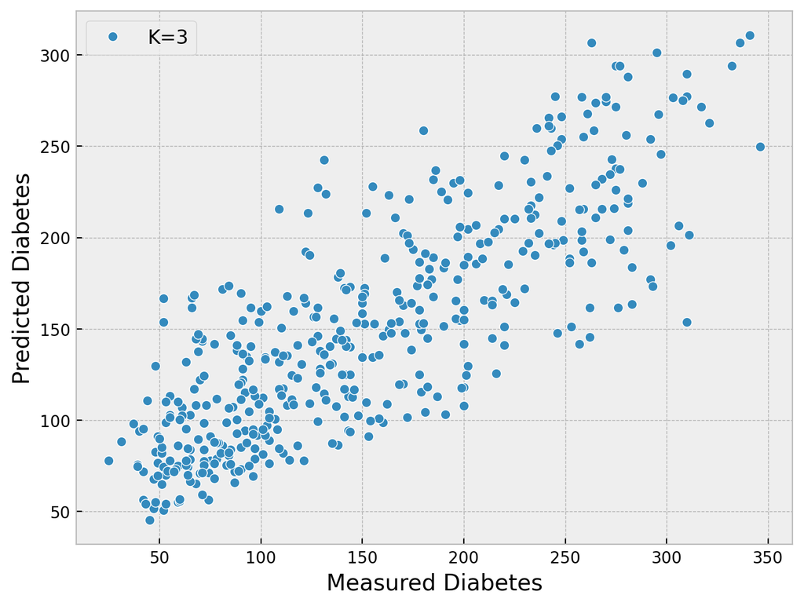

```python
plt.plot(y, knn3_y_prediction, 'o', label='K=3')
plt.xlabel('Measured Diabetes')
plt.ylabel('Predicted Diabetes')
plt.legend();
```

But how many neighbors should we consider? i.e. K = ?

K is a hyperparameter that defines one of many possible KNN models.

# Exercise

Use a K=5 model to fit the relationship between patient features and diabetes score.

```python
# 1. create the model...
#model = ...

# 2. fit the model to the data...
#...

# 3. compute the residuals...
#y_prediction = ...
#residuals = ...

# 4. compute the MSE...
#MSE = ...
```

# Exercise key

Use a K=5 model to fit the relationship between patient features and diabetes score.

```python
# 1. create the model...
model = KNeighborsRegressor(n_neighbors=5)

# 2. fit the model to the data...
model.fit(X, y)

# 3. compute the residuals...
y_prediction = model.predict(X)
residuals = y - y_prediction

# 4. compute the MSE...
MSE = np.mean(residuals**2)
```

Compare some different values for K.

```python
models = [
    KNeighborsRegressor(n_neighbors=2),
    KNeighborsRegressor(n_neighbors=10),
    KNeighborsRegressor(n_neighbors=50)
]

for model in models:
    model.fit(X, y);
```

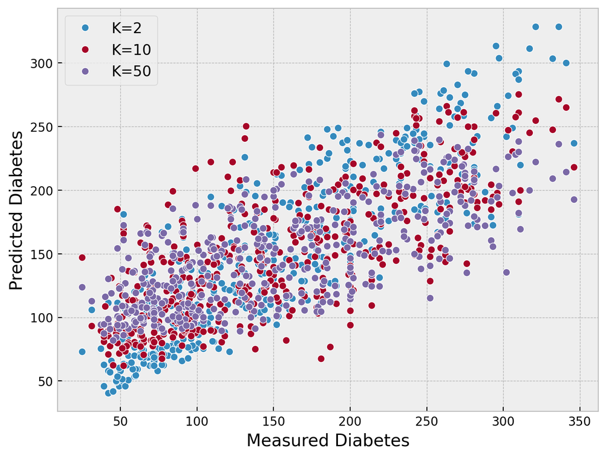

```python
for model in models:
    plt.plot(y, model.predict(X), 'o', label=f'K={model.n_neighbors}')
plt.xlabel('Measured Diabetes')
plt.ylabel('Predicted Diabetes')
plt.legend();
```

```python
K = []
MSE = []
for model in models:
    y_pred = model.predict(X)
    residuals = y - y_pred
    K.append(f'K={model.n_neighbors}')
    MSE.append(np.mean(residuals**2))

K, MSE
```

```
(['K=2', 'K=10', 'K=50'],
 [1471.9078054298643, 2744.486606334842, 3226.2884298642534])
```

```python
import pandas as pd
pd.DataFrame(MSE, index=K, columns=['MSE'])
```

|  | MSE |
| --- | --- |
| K=2 | 1471.907805 |
| K=10 | 2744.486606 |
| K=50 | 3226.288430 |

But how do we determine which K is best?

Clearly, we can't use mean squared error (MSE), because K=1 would always be best even though it is just fitting noise in the data.

We'll discuss this next lecture...